# Binary Classification Model for MiniBooNE Particle Identification Using R Take 3

David Lowe

January 14, 2019

Template Credit: Adapted from a template made available by Dr. Jason Brownlee of Machine Learning Mastery. [https://machinelearningmastery.com/]

SUMMARY: The purpose of this project is to construct a prediction model using various machine learning algorithms and to document the end-to-end steps using a template. The MiniBooNE Particle Identification dataset is a classic binary classification situation where we are trying to predict one of the two possible outcomes.

INTRODUCTION: This dataset is taken from the MiniBooNE experiment and is used to distinguish electron neutrinos (signal) from muon neutrinos (background). The data file is set up as follows. In the first line is the number of signal events followed by the number of background events. The records with the signal events come first, followed by the background events. Each line, after the first line, has the 50 particle ID variables for one event.

In iteration Take1, the script focused on evaluating various machine learning algorithms and identifying the model that produces the best overall metrics. Iteration Take1 established the baseline performance for accuracy and processing time.

In iteration Take2, we examined the feature selection technique of eliminating collinear features. By eliminating the collinear features, we hoped to decrease the processing time and maintain a similar level of accuracy compared to iteration Take1.

For this iteration, we will examine the feature selection technique of attribute importance ranking. By taking only the most important attributes, we hoped to decrease the processing time and maintain a similar level of accuracy compared to iterations Take1 and Take2.

ANALYSIS: From the previous iteration Take1, the baseline performance of the eight algorithms achieved an average accuracy of 90.82%. Two algorithms (Bagged CART and Random Forest) achieved the top accuracy scores after the first round of modeling. After a series of tuning trials, Random Forest turned in the top result using the training data. It achieved an average accuracy of 93.74%. By optimizing the tuning parameters, the Random Forest algorithm processed the testing dataset with an accuracy of 93.91%, which was even better than the training data.

From the previous iteration Take2, the baseline performance of the machine learning algorithms achieved an average accuracy of 90.04%. Two algorithms (Stochastic Gradient Boosting and Random Forest) achieved the top accuracy metrics after the first round of modeling. After a series of tuning trials, Stochastic Gradient Boosting turned in the top overall result and achieved an accuracy metric of 93.47%. By using the optimized parameters, the Stochastic Gradient Boosting algorithm processed the testing dataset with an accuracy of 93.57%, which was even better than the training data.

From the model-building perspective, the number of attributes decreased by 25, from 50 down to 25 in iteration Take3. The processing time went from 17 hours 18 minutes in iteration Take1 down to 6 hours 48 minutes in Take3, which was a reduction of 60.6% from Take1. It was also a significant decrease in comparison to Take2, which had a processing time of 12 hours 17 minutes.

CONCLUSION: For this iteration, the Random Forest algorithm achieved the best overall results with an improved processing time after eliminating the unimportant features. For this dataset, the Stochastic Gradient Boosting and Random Forest algorithms should be considered for further modeling or production use.

Dataset Used: MiniBooNE particle identification Data Set

Dataset ML Model: Binary classification with numerical attributes

Dataset Reference: https://archive.ics.uci.edu/ml/datasets/MiniBooNE+particle+identification

The project aims to touch on the following areas:

1. Document a predictive modeling problem end-to-end.
2. Explore data cleaning and transformation options
3. Explore non-ensemble and ensemble algorithms for baseline model performance
4. Explore algorithm tuning techniques for improving model performance

Any predictive modeling machine learning project genrally can be broken down into about six major tasks:

1. Prepare Problem
2. Summarize Data
3. Prepare Data
4. Model and Evaluate Algorithms
5. Improve Accuracy or Results
6. Finalize Model and Present Results

## 1. Prepare Problem

### 1.a) Load libraries

```r
startTimeScript <- proc.time()
library(caret)
```

```r
library(corrplot)
library(mailR)
library(stringr)
library(MLmetrics)
library(DMwR)
library(ROCR)
# Create one random seed number for reproducible results
seedNum <- 888
set.seed(seedNum)
```

### 1.b) Set up the email notification function

```r
email_notify <- function(msg=""){
  sender <- "luozhi2488@gmail.com"
  receiver <- "dave@contactdavidlowe.com"
  sbj_line <- "Notification from R Script"
  password <- readLines("../email_credential.txt")
  send.mail(
    from = sender,
    to = receiver,
    subject= sbj_line,
    body = msg,
    smtp = list(host.name = "smtp.gmail.com", port = 465, user.name = sender, passwd = password, ssl = TRUE),
    authenticate = TRUE,
    send = TRUE)
}
```

```r
email_notify(paste("Library and Data Loading has begun!",date()))
```

```
## [1] "Java-Object{org.apache.commons.mail.SimpleEmail@3c0f93f1}"
```

### 1.c) Load dataset

```r
# Process the first line of the input file with the meta information
con <- file("MiniBooNE_PID.txt","r")
first_line <- readLines(con,n=1)
str_split(first_line, " ")[1]
```

```
## [[1]]
## [1] ""      "36499" "93565"
```

```r
close(con)
signal_rec <- as.numeric(str_split(first_line," ")[[1]][2])
background_rec <- as.numeric(str_split(first_line," ")[[1]][3])

# Process the remainder of the input file and capture the fixed length records
widthVector <- rep(14, 50)
colNames <- paste0("attr",1:50)
xy_original <- read.fwf("MiniBooNE_PID.txt", widths=widthVector, skip=1, col.names=colNames)
xy_original$targetVar <- "background"
xy_original[1:signal_rec,"targetVar"] <- "signal"
xy_original$targetVar <- as.factor(xy_original$targetVar)
xy_original$targetVar <- relevel(xy_original$targetVar,"signal")
```

```r
# Use variable totCol to hold the number of columns in the dataframe
totCol <- ncol(xy_original)

# Set up variable totAttr for the total number of attribute columns
totAttr <- totCol-1
```

```r
# targetCol variable indicates the column location of the target/class variable
# If the first column, set targetCol to 1. If the last column, set targetCol to totCol
# if (targetCol <> 1) and (targetCol <> totCol), be aware when slicing up the dataframes for visualization!
targetCol <- totCol
colnames(xy_original)[targetCol] <- "targetVar"
```

```r
# We create training datasets (xy_train, x_train, y_train) for various operations.
# We create test datasets (xy_test, x_test, y_test) for various operations.
set.seed(seedNum)

# Create a list of the rows in the original dataset we can use for training
training_index <- createDataPartition(xy_original$targetVar, p=0.70, list=FALSE)
# Use 70% of the data to train the models and the remaining for testing/validation
xy_train <- xy_original[training_index,]
xy_test <- xy_original[-training_index,]

if (targetCol==1) {
x_train <- xy_train[,(targetCol+1):totCol]
y_train <- xy_train[,targetCol]
y_test <- xy_test[,targetCol]
} else {
x_train <- xy_train[,1:(totAttr)]
y_train <- xy_train[,totCol]
y_test <- xy_test[,totCol]
}
```

### 1.d) Set up the key parameters to be used in the script

```r
# Set up the number of row and columns for visualization display. dispRow * dispCol should be >= totAttr
dispCol <- 4
if (totAttr%%dispCol == 0) {
dispRow <- totAttr%/%dispCol
} else {
dispRow <- (totAttr%/%dispCol) + 1
}
cat("Will attempt to create graphics grid (col x row): ", dispCol, ' by ', dispRow)
```

```
## Will attempt to create graphics grid (col x row):  4  by  13
```

### 1.e) Set test options and evaluation metric

```r
# Run algorithms using 10-fold cross validation
control <- trainControl(method="repeatedcv", number=10, repeats=1)
metricTarget <- "Accuracy"
```

```r
email_notify(paste("Library and Data Loading completed!",date()))
```

```
## [1] "Java-Object{org.apache.commons.mail.SimpleEmail@a67c67e}"
```

## 2. Summarize Data

To gain a better understanding of the data that we have on-hand, we will leverage a number of descriptive statistics and data visualization techniques. The plan is to use the results to consider new questions, review assumptions, and validate hypotheses that we can investigate later with specialized models.

```r
email_notify(paste("Data Summarization and Visualization has begun!",date()))
```

```
## [1] "Java-Object{org.apache.commons.mail.SimpleEmail@78c03f1f}"
```

### 2.a) Descriptive statistics

#### 2.a.i) Peek at the data itself.

```r
head(xy_train)
```

```
##     attr1    attr2    attr3    attr4      attr5    attr6    attr7    attr8
## 1 2.59413 0.468803  20.6916 0.322648 0.00968188 0.374393 0.803479 0.896592
## 3 3.38584 1.197140  36.0807 0.200866 0.01734100 0.260841 1.108950 0.884405
## 4 4.28524 0.510155 674.2010 0.281923 0.00917431 0.000000 0.998822 0.823390
## 5 5.93662 0.832993  59.8796 0.232853 0.02506600 0.233556 1.370040 0.787424
## 6 4.41251 2.157210  66.7853 0.335389 0.00427350 0.133690 0.696868 0.753386
## 7 3.41292 0.834852  45.5963 0.253942 0.00947867 0.290691 1.273870 0.891223
##     attr9   attr10  attr11   attr12    attr13   attr14  attr15   attr16
## 1 3.59665 0.249282 4.18624 135.8850  0.928671 0.140918 2.58663 1689.070
## 3 3.43159 0.177167 4.50807 159.3960  0.412250 0.434002 2.38485  992.098
## 4 3.16382 0.171678 4.08041  -1.8656  0.833067 0.181294 2.49837 1289.160
## 5 3.66546 0.174862 4.59180 183.6680  0.398421 0.353034 2.04136  949.231
## 6 3.45575 0.150908 4.43856 283.4460 -0.463347 0.130846 1.55108  507.203
## 7 3.42853 0.227561 4.44664 206.0020  0.836173 0.165293 2.50378 1236.870
##     attr17  attr18   attr19   attr20     attr21   attr22   attr23  attr24
```

[output cut: 34 more lines]

#### 2.a.ii) Dimensions of the dataset.

```r
dim(xy_train)
```

```
## [1] 91046    51
```

#### 2.a.iii) Types of the attributes.

```r
sapply(xy_train, class)
```

```
##     attr1     attr2     attr3     attr4     attr5     attr6     attr7
## "numeric" "numeric" "numeric" "numeric" "numeric" "numeric" "numeric"
##     attr8     attr9    attr10    attr11    attr12    attr13    attr14
## "numeric" "numeric" "numeric" "numeric" "numeric" "numeric" "numeric"
##    attr15    attr16    attr17    attr18    attr19    attr20    attr21
## "numeric" "numeric" "numeric" "numeric" "numeric" "numeric" "numeric"
##    attr22    attr23    attr24    attr25    attr26    attr27    attr28
## "numeric" "numeric" "numeric" "numeric" "numeric" "numeric" "numeric"
##    attr29    attr30    attr31    attr32    attr33    attr34    attr35
## "numeric" "numeric" "numeric" "numeric" "numeric" "numeric" "numeric"
##    attr36    attr37    attr38    attr39    attr40    attr41    attr42
## "numeric" "numeric" "numeric" "numeric" "numeric" "numeric" "numeric"
##    attr43    attr44    attr45    attr46    attr47    attr48    attr49
## "numeric" "numeric" "numeric" "numeric" "numeric" "numeric" "numeric"
##    attr50 targetVar
## "numeric"  "factor"
```

#### 2.a.iv) Statistical summary of all attributes.

```r
summary(xy_train)
```

```
##      attr1              attr2               attr3
##  Min.   :-999.000   Min.   :-999.0000   Min.   :-999.00
##  1st Qu.:   4.013   1st Qu.:   0.8765   1st Qu.:  49.75
##  Median :   4.786   Median :   1.3844   Median : 106.32
##  Mean   :   1.213   Mean   :  -2.1458   Mean   : 124.09
##  3rd Qu.:   5.625   3rd Qu.:   1.9462   3rd Qu.: 138.98
##  Max.   :  17.057   Max.   :   8.8028   Max.   :4622.80
##      attr4               attr5               attr6
##  Min.   :-999.0000   Min.   :-999.0000   Min.   :-999.0000
##  1st Qu.:   0.2418   1st Qu.:   0.0000   1st Qu.:   0.0848
##  Median :   0.2721   Median :   0.0050   Median :   0.1408
##  Mean   :  -3.3497   Mean   :  -3.6226   Mean   :  -3.4722
##  3rd Qu.:   0.3152   3rd Qu.:   0.0131   3rd Qu.:   0.2118
##  Max.   :   0.7042   Max.   :   0.1790   Max.   :   0.7039
##      attr7               attr8               attr9
##  Min.   :-999.0000   Min.   :-999.0000   Min.   :-999.0000
##  1st Qu.:   0.7145   1st Qu.:   0.7834   1st Qu.:   3.2843
##  Median :   0.9222   Median :   0.8338   Median :   3.4271
##  Mean   :  -2.6655   Mean   :  -2.8109   Mean   :  -0.1934
##  3rd Qu.:   1.1798   3rd Qu.:   0.8741   3rd Qu.:   3.5855
##  Max.   :   6.2411   Max.   :   0.9897   Max.   :   7.1702
##      attr10              attr11              attr12
##  Min.   :-999.0000   Min.   :-999.0000   Min.   :-999.00
##  1st Qu.:   0.1430   1st Qu.:   4.1505   1st Qu.:  73.01
##  Median :   0.1706   Median :   4.2889   Median : 155.70
##  Mean   :  -3.4586   Mean   :   0.6721   Mean   : 161.32
##  3rd Qu.:   0.1999   3rd Qu.:   4.4345   3rd Qu.: 244.65
##  Max.   :   0.5249   Max.   :   9.5593   Max.   : 535.00
##      attr13              attr14              attr15
##  Min.   :-999.0000   Min.   :-999.0000   Min.   :-999.000
##  1st Qu.:   0.1508   1st Qu.:   0.1115   1st Qu.:   1.779
##  Median :   0.6315   Median :   0.2435   Median :   2.095
##  Mean   :  -3.1828   Mean   :  -3.3228   Mean   :  -1.389
##  3rd Qu.:   0.8733   3rd Qu.:   0.4689   3rd Qu.:   2.525
##  Max.   :   1.0000   Max.   :   1.0000   Max.   :  11.296
##      attr16           attr17              attr18
##  Min.   :-999.0   Min.   :-999.0000   Min.   :-999.000
##  1st Qu.: 562.5   1st Qu.:   0.2136   1st Qu.:   9.906
##  Median : 732.2   Median :   0.3145   Median :  18.274
##  Mean   : 933.8   Mean   :  -3.1780   Mean   :  23.251
```

[output cut: 64 more lines]

```
##  Max.   :  43.6512   Max.   :  85.823   Max.   :   0.4469
##      attr46              attr47              attr48
##  Min.   :-999.0000   Min.   :-999.0000   Min.   :-999.0000
##  1st Qu.:   0.1221   1st Qu.:  -0.3452   1st Qu.:   1.4225
##  Median :   0.1689   Median :   0.0409   Median :   2.3680
##  Mean   :  -3.4534   Mean   :  -3.7898   Mean   :  -0.7801
##  3rd Qu.:   0.2250   3rd Qu.:   0.2943   3rd Qu.:   3.7808
##  Max.   :   0.6057   Max.   :   1.9329   Max.   :  18.6026
##      attr49              attr50               targetVar
##  Min.   :-999.0000   Min.   :-999.0000   signal    :25550
##  1st Qu.:   0.2726   1st Qu.:   0.1973   background:65496
##  Median :   1.1253   Median :   0.2314
##  Mean   :  -2.0232   Mean   :  -3.4021
##  3rd Qu.:   2.2794   3rd Qu.:   0.2631
##  Max.   :  24.2728   Max.   :   0.6255
```

#### 2.a.v) Summarize the levels of the class attribute.

```r
cbind(freq=table(y_train), percentage=prop.table(table(y_train))*100)
```

```
##             freq percentage
## signal     25550   28.06274
## background 65496   71.93726
```

#### 2.a.vi) Count missing values.

```r
sapply(xy_train, function(x) sum(is.na(x)))
```

```
##     attr1     attr2     attr3     attr4     attr5     attr6     attr7
##         0         0         0         0         0         0         0
##     attr8     attr9    attr10    attr11    attr12    attr13    attr14
##         0         0         0         0         0         0         0
##    attr15    attr16    attr17    attr18    attr19    attr20    attr21
##         0         0         0         0         0         0         0
##    attr22    attr23    attr24    attr25    attr26    attr27    attr28
##         0         0         0         0         0         0         0
##    attr29    attr30    attr31    attr32    attr33    attr34    attr35
##         0         0         0         0         0         0         0
##    attr36    attr37    attr38    attr39    attr40    attr41    attr42
##         0         0         0         0         0         0         0
##    attr43    attr44    attr45    attr46    attr47    attr48    attr49
##         0         0         0         0         0         0         0
##    attr50 targetVar
##         0         0
```

### 2.b) Data visualizations

#### 2.b.i) Univariate plots to better understand each attribute.

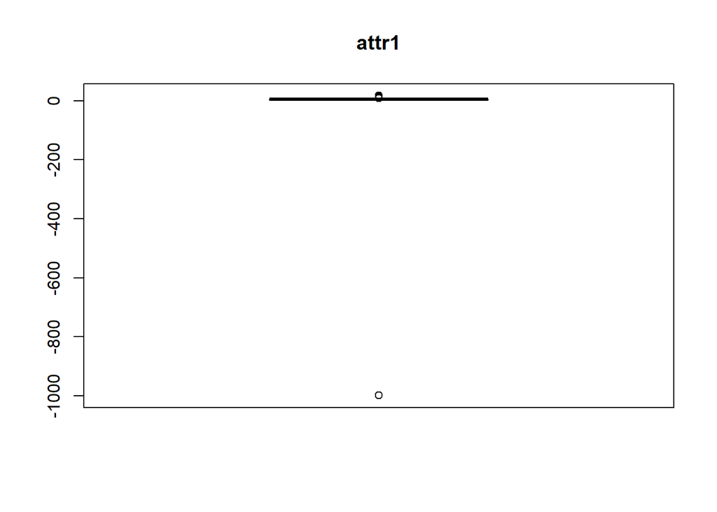

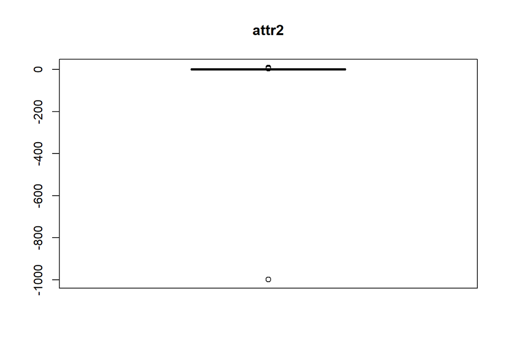

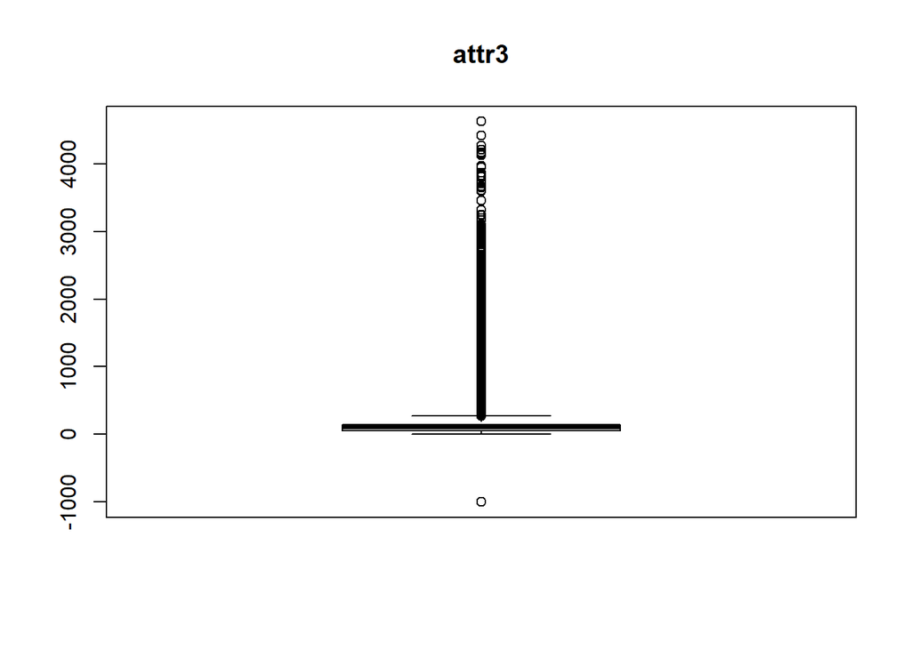

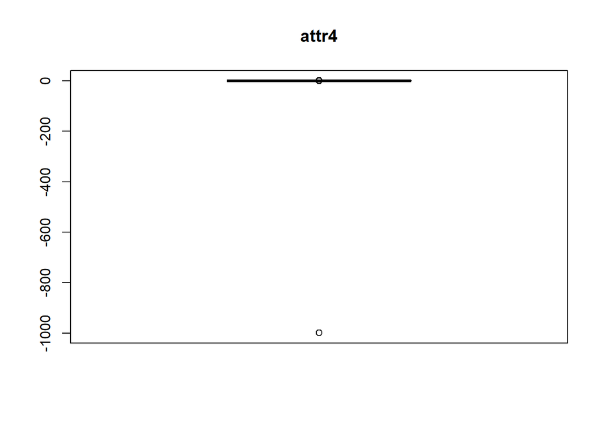

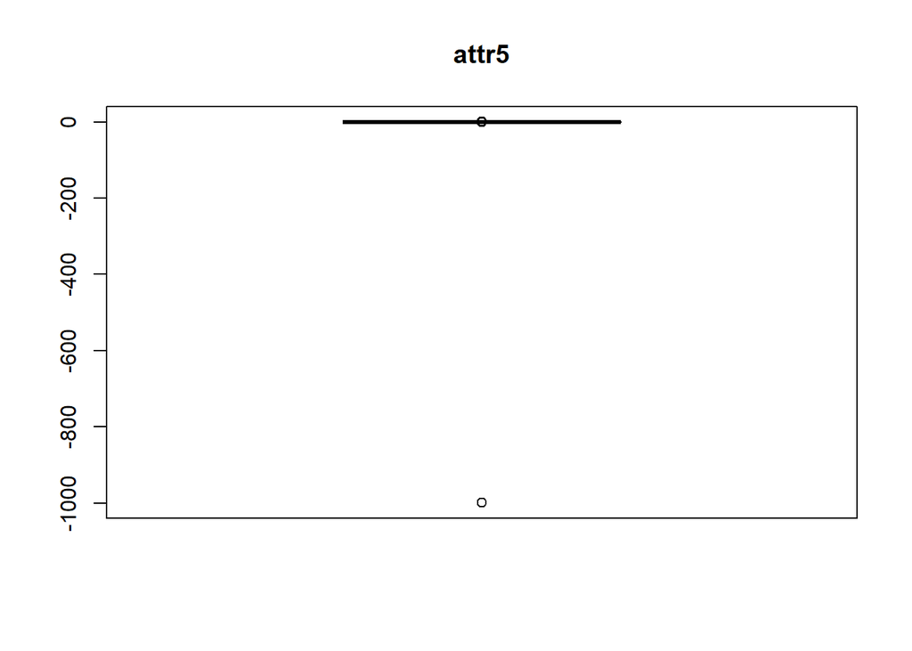

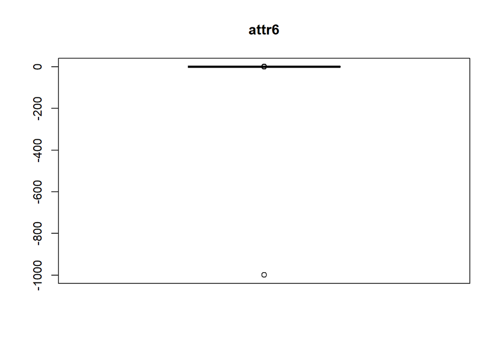

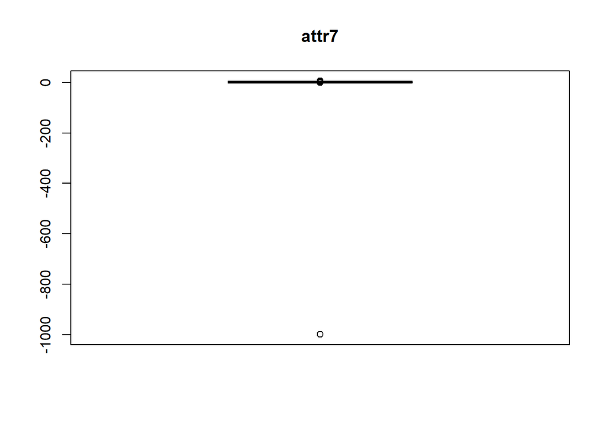

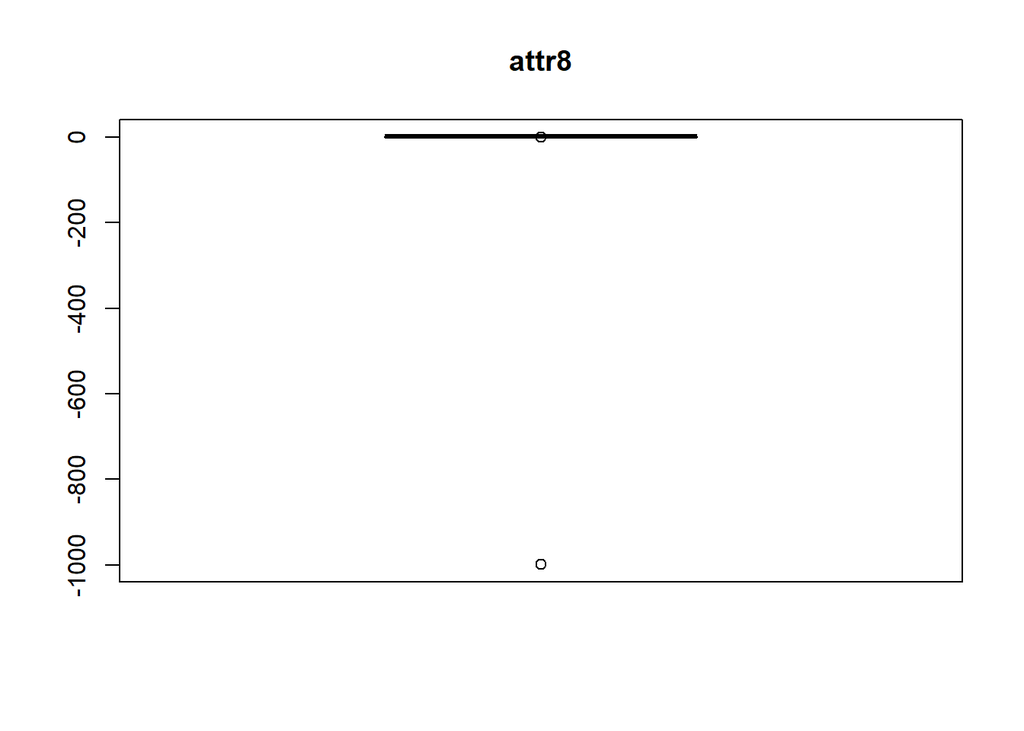

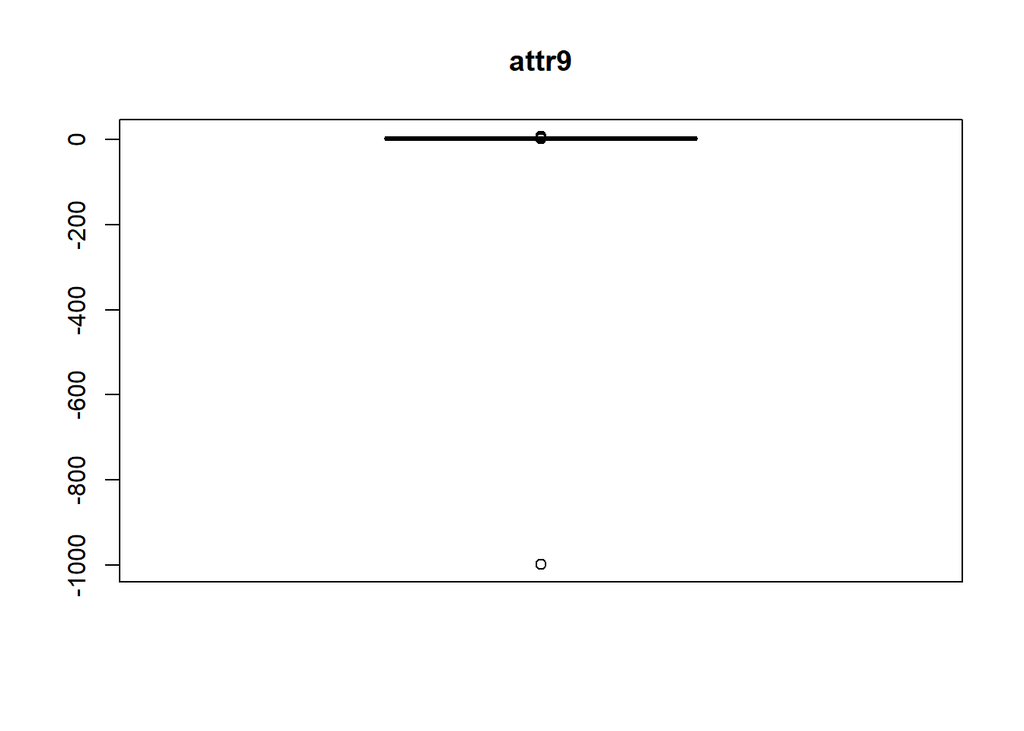

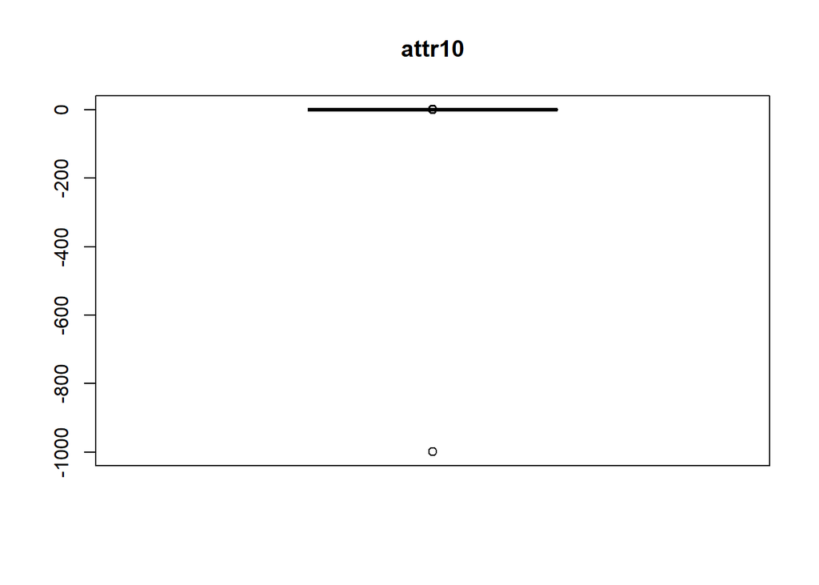

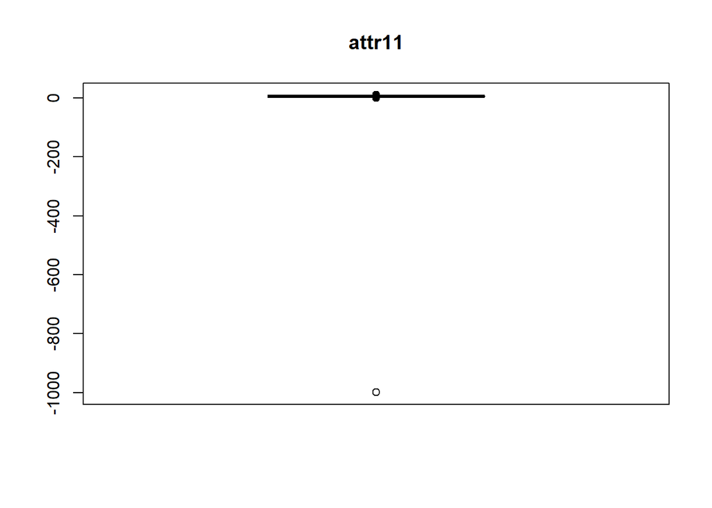

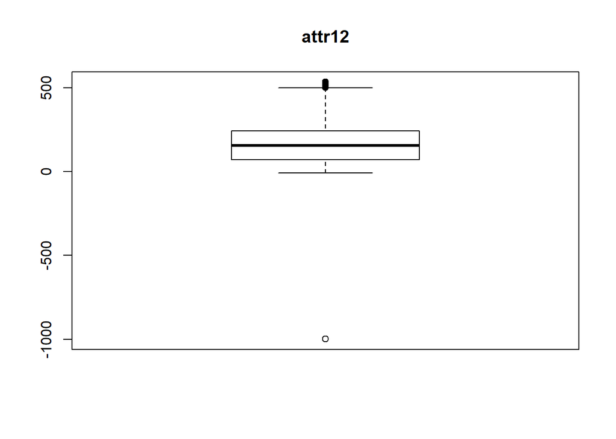

[38 more figures not shown]

```r
# Boxplots for each attribute
# par(mfrow=c(dispRow,dispCol))
for(i in 1:totAttr) {
    boxplot(x_train[,i], main=names(x_train)[i])
}
```

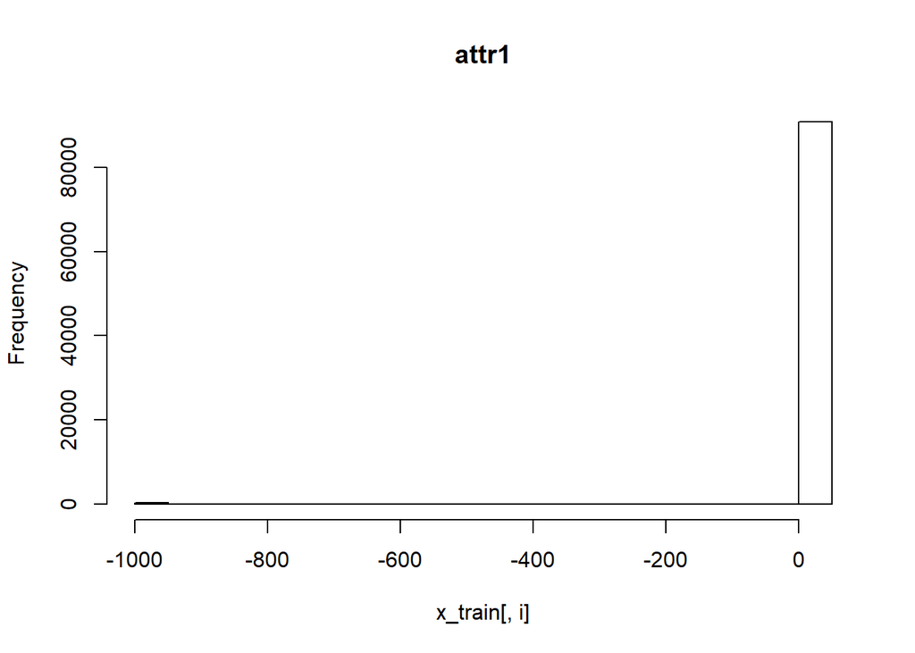

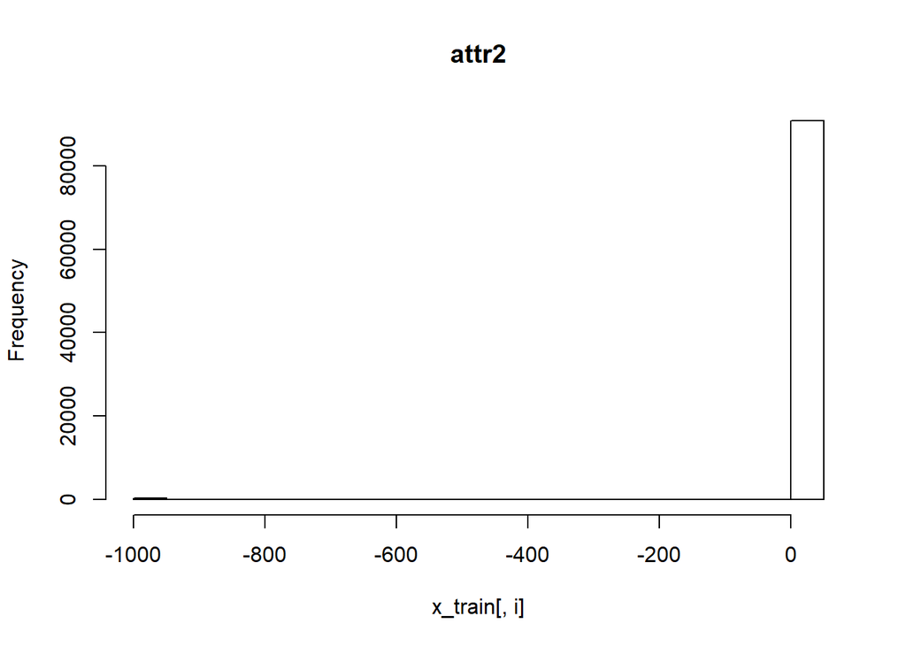

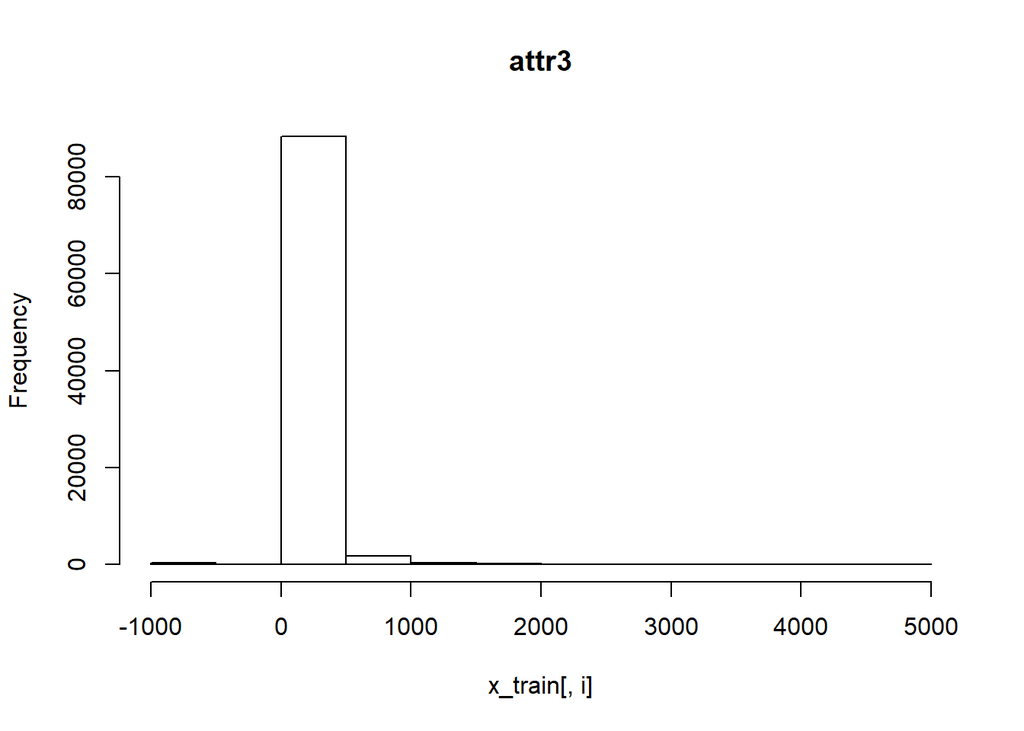

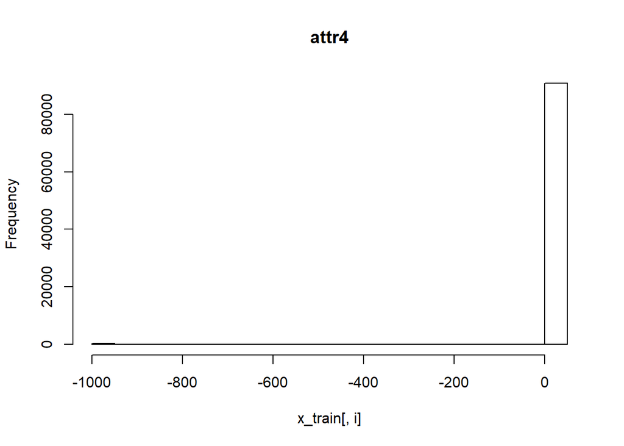

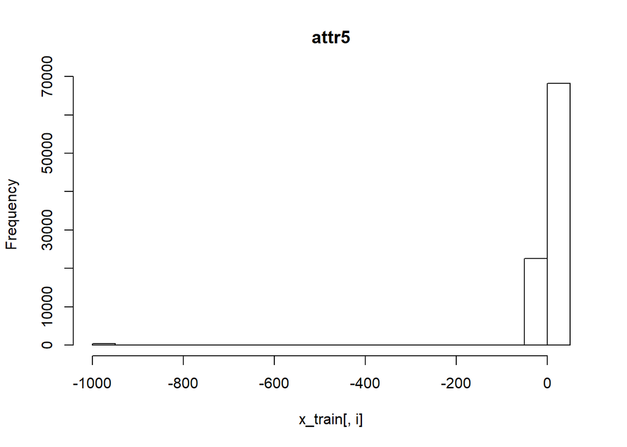

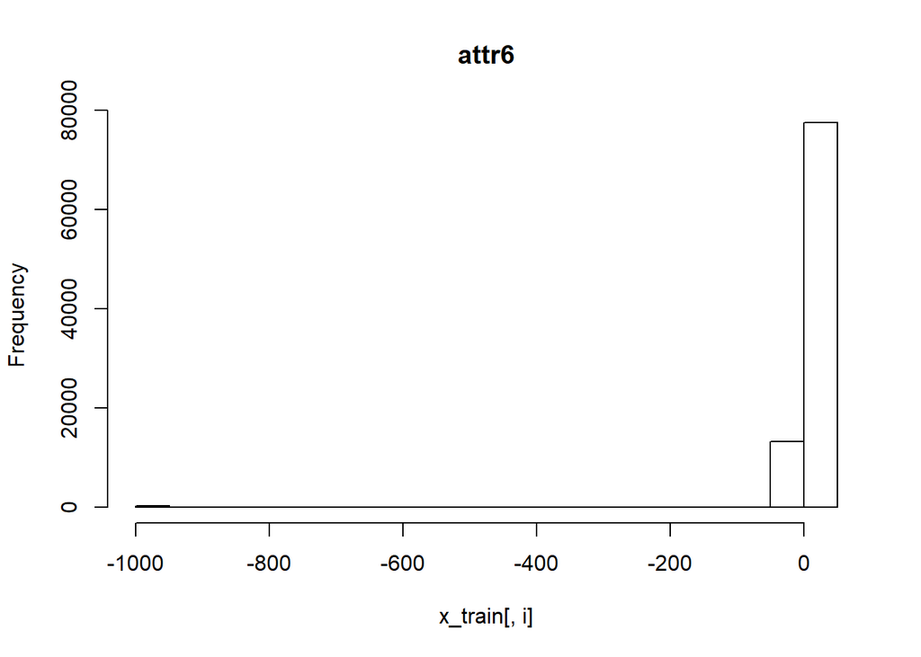

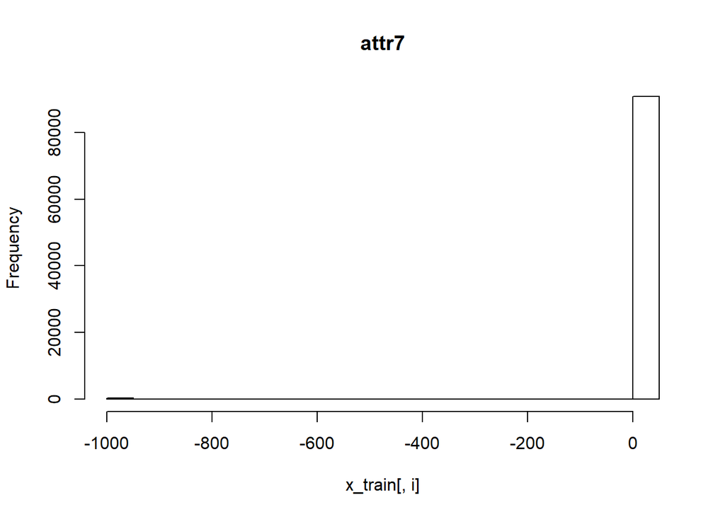

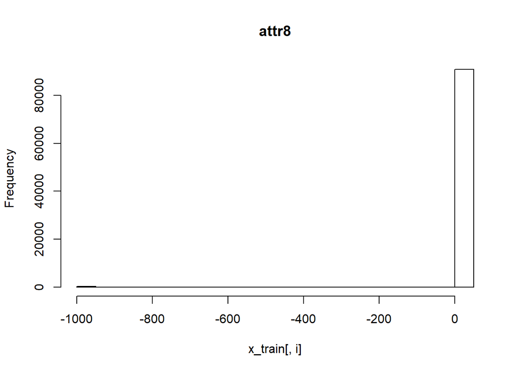

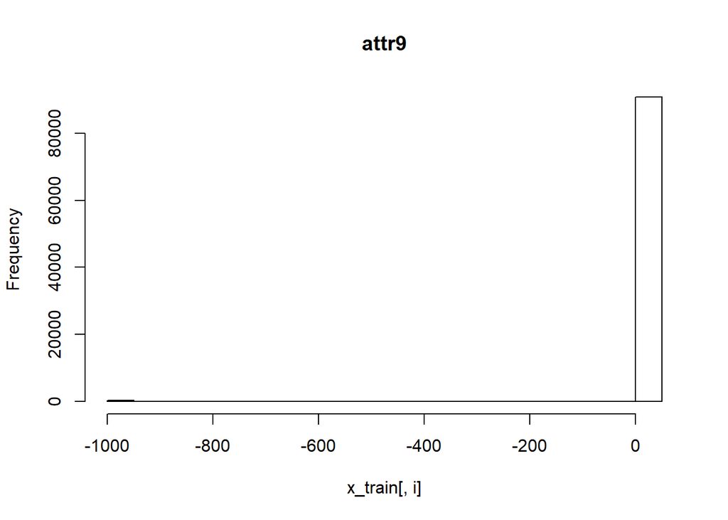

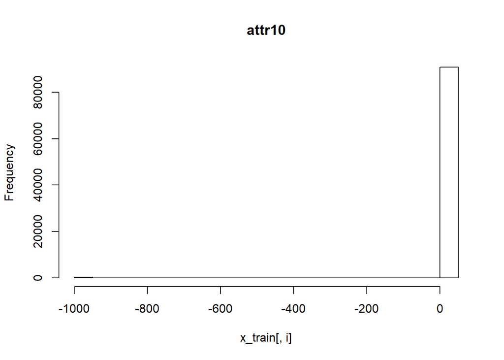

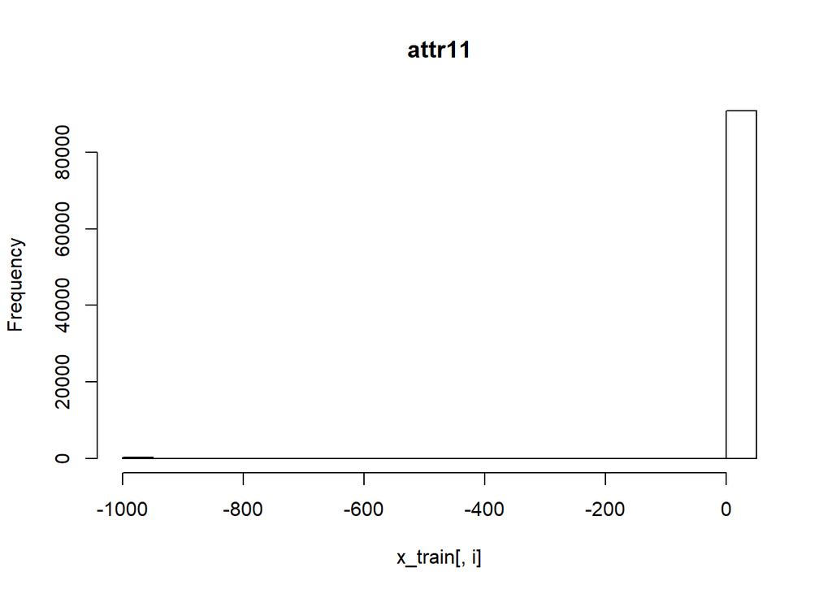

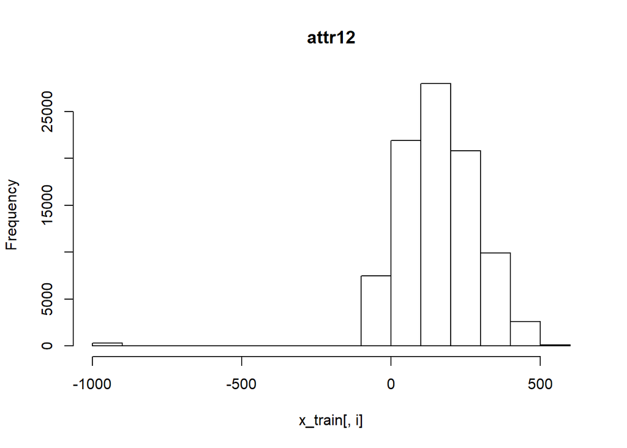

[38 more figures not shown]

```r
# Histograms each attribute
# par(mfrow=c(dispRow,dispCol))
for(i in 1:totAttr) {
    hist(x_train[,i], main=names(x_train)[i])
}
```